# New York State Hospital Discharges - 2014

### Length of Stay and Admission/Discharge Day

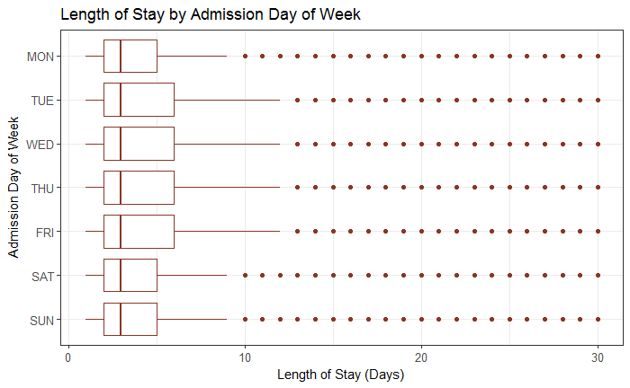

```r
inlier_los$Admit.Day.of.Week <- factor(inlier_los$Admit.Day.of.Week,levels = c('SUN','SAT','FRI','THU','WED','TUE','MON'))
ggplot(inlier_los, aes(x=Admit.Day.of.Week, y=Length.of.Stay)) + geom_boxplot(outlier.alpha=0.5, color="tomato4") + coord_flip() + theme_bw() + theme(axis.text = element_text(size=10)) + xlab("Admission Day of Week") + ylab("Length of Stay (Days)") + ggtitle("Length of Stay by Admission Day of Week")
```

I first attempted to look at length of stay by day of admission for the entire dataset, but found that the outliers at the extreme end of the dataset made each day look more or less exactly the same. Instead, I went back to the inliers subset I had created for the diagnostic length of stay analysis earlier. While the median length of stay is the same for admissions and any day of the week, admissions beginning on Tuesday, Wednesday, Thursday, or Friday appear more likely to have longer lengths of stay. To investigate this, I checked whether more medical or surgical admissions were occurring each day of the week.

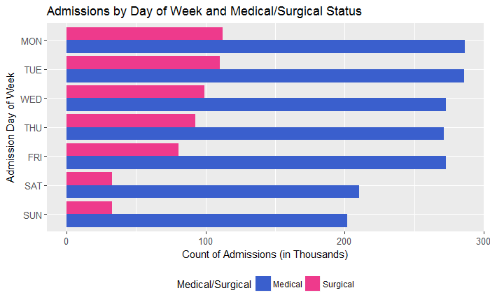

```r
hosp_clean$Admit.Day.of.Week <- factor(hosp_clean$Admit.Day.of.Week,levels = c('SUN','SAT','FRI','THU','WED','TUE','MON'))
ggplot(hosp_clean[which(!is.na(hosp_clean$APR.Medical.Surgical.Description)),], aes(Admit.Day.of.Week, fill=APR.Medical.Surgical.Description)) + geom_bar(stat="count", position=position_dodge()) + coord_flip() + scale_fill_manual(values=c('royalblue3','violetred2'), name="Medical/Surgical") + xlab("Admission Day of Week") + ylab("Count of Admissions (in Thousands)") + ggtitle("Admissions by Day of Week and Medical/Surgical Status") + theme(axis.text = element_text(size=10), legend.position = "bottom") + scale_y_continuous(labels=function(x)x/1000)
```

While the majority of admissions on any day of the week were for medical procedures, there were significantly more surgical admissions on Mondays and Tuesdays. Many surgeries are often scheduled for Mondays based on my limited knowledge of hospital scheduling, so I expected to see a larger proportion of surgical admissions on Mondays, leading to the shorter average length of stay for admissions beginning that day. This does not appear to entirely be the case, though it could be a contributing factor. I also checked whether discharge day of week showed correlation with length of stay.

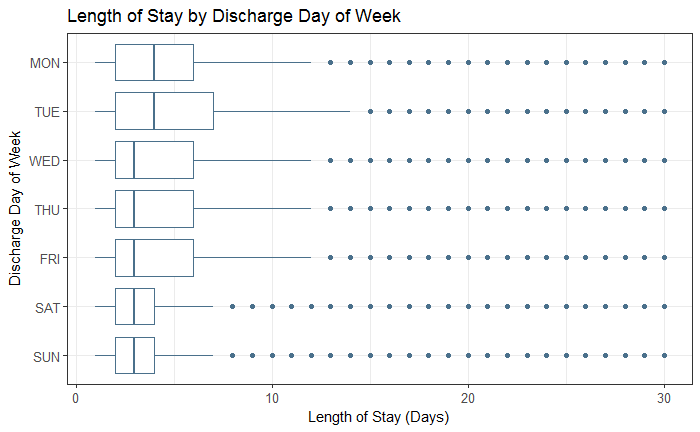

```r
inlier_los$Discharge.Day.of.Week <- factor(inlier_los$Discharge.Day.of.Week,levels = c('SUN','SAT','FRI','THU','WED','TUE','MON'))
ggplot(inlier_los, aes(x=Discharge.Day.of.Week, y=Length.of.Stay)) + geom_boxplot(outlier.alpha=0.5, color="skyblue4") + coord_flip() + theme_bw() + theme(axis.text = element_text(size=10)) + xlab("Discharge Day of Week") + ylab("Length of Stay (Days)") + ggtitle("Length of Stay by Discharge Day of Week")
```

I assumed that admissions of a greater length would be more likely to be discharged on a weekday than over the weekend, which does appear to be the case. Interestingly, the largest interquartile range is for inpatient admissions ending on Tuesdays. It is unclear from this analysis why this might be. Discharges on Mondays had the same median length of stay as those on Tuesdays, though with a lower IQR. The relatively small number of discharges over the weekend could be contributing to this longer length of stay on Mondays and Tuesdays - perhaps patients admitted on Thursday or Friday are likely to stay until after the weekend and have a greater length of stay by two to three days.

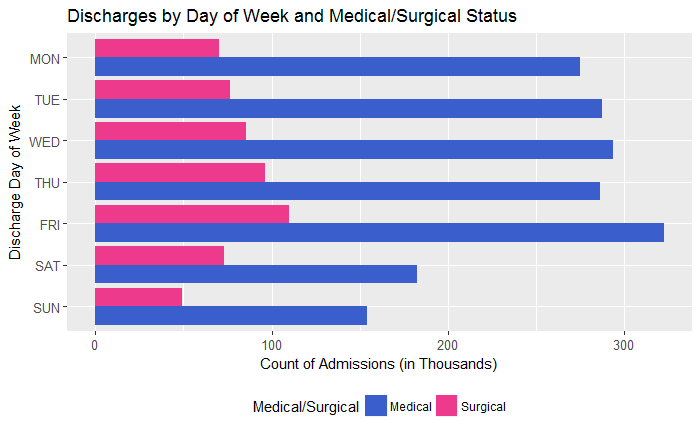

```r
hosp_clean$Discharge.Day.of.Week <- factor(hosp_clean$Discharge.Day.of.Week,levels = c('SUN','SAT','FRI','THU','WED','TUE','MON'))
ggplot(hosp_clean[which(!is.na(hosp_clean$APR.Medical.Surgical.Description)),], aes(Discharge.Day.of.Week, fill=APR.Medical.Surgical.Description)) + geom_bar(stat="count", position=position_dodge()) + coord_flip() + scale_fill_manual(values=c('royalblue3','violetred2'), name="Medical/Surgical") + xlab("Discharge Day of Week") + ylab("Count of Admissions (in Thousands)") + ggtitle("Discharges by Day of Week and Medical/Surgical Status") + theme(axis.text = element_text(size=10), legend.position = "bottom") + scale_y_continuous(labels=function(x)x/1000)
```

I created the same medical/surgical admissions chart for discharge day of week as I did for admission day of week. For surgical admissions, the likelihood of being discharged increases with each weekday, with the most patients discharged on Fridays. The most medical admissions are also discharged on Fridays, though the relationship between weekdays and number of discharges is not as linear for these admissions.

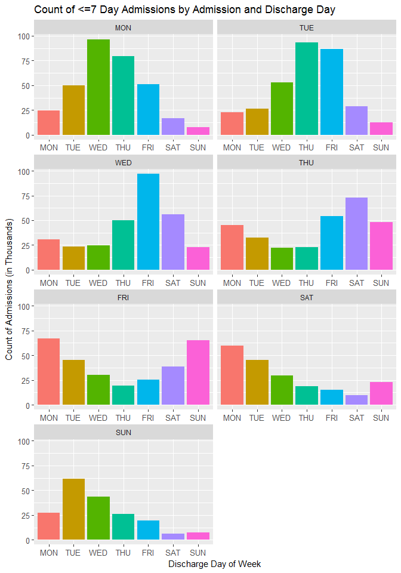

```r
week_admits <- hosp_clean[which(hosp_clean$Length.of.Stay <= 7),]
week_admits$Discharge.Day.of.Week <- factor(week_admits$Discharge.Day.of.Week,levels = c('MON','TUE','WED','THU','FRI','SAT','SUN'))
week_admits$Admit.Day.of.Week <- factor(week_admits$Admit.Day.of.Week,levels = c('MON','TUE','WED','THU','FRI','SAT','SUN'))
ggplot(week_admits, aes(Discharge.Day.of.Week)) + geom_bar(stat="count", aes(fill=Discharge.Day.of.Week)) + facet_wrap(~Admit.Day.of.Week,ncol=2,nrow=4,scales="free_x") + scale_y_continuous(labels=function(x)x/1000) + xlab("Discharge Day of Week") + ylab("Count of Admissions (in Thousands)") + guides(fill=FALSE) + ggtitle("Count of <=7 Day Admissions by Admission and Discharge Day") + theme(axis.text = element_text(size=10))
```

To investigate the impact of the day of week on admissions and discharges, I subsetted the dataset to include only admissions lasting 7 days or less. This included 1,937,436 admissions, about 82% of the full dataset. I created a facet wrap plot for each admission day of week showing the discharge day of week for those admissions to further investigate the theory that patients admitted over the weekend were more likely to stay for more days and be discharged during the workweek. It appears that this is, for the most part, true. With the exception of patients admitted on Fridays, where patients were equally likely to be discharged two and three days following admission, patients staying a week or less are most likely to be discharged two days after their admission.  
Patients admitted on Mondays were most often discharged on Wednesdays, then on Thursdays, and were unlikely to be discharged over the weekend. Those admitted on Tuesdays were most likely to be discharged on Thursdays, then Fridays. Admissions on Wednesdays were very likely to end on Fridays, more so than the admissions on other days of the week ending two days later. Patients admitted on Thursdays were most likely to be discharged on a Saturday, perhaps indicating that the tendency to discharge on a business day is outweighed by the tendency to discharge two days after admission. However, admissions beginning on Fridays were about equally likely to end on Sundays or Mondays. Saturday admissions were most often discharged on Monday, followed by Tuesday. Finally, Sunday admissions most frequently ended on Tuesdays, then on Wednesdays, and were the least likely of all admissions to end on a weekend.

## Charges and Costs

Finally, I briefly investigated the data on admission charges and costs available in the dataset. Due to the size of the dataset, this was the most difficult to visualize and interpret of the analysis I performed. I attempted to create a scatterplot of charges vs cost, but the sheer volume of data made this impossible to visualize clearly. I also tried to create a slope graph, using a parallel coordinate plot framework to look at the relationship between charges and costs, but found that the volume of data again made this impossible.

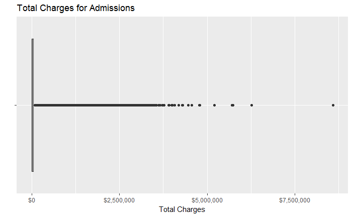

```r
ggplot(hosp_clean, aes(y=Total.Charges, x="")) + geom_boxplot() + coord_flip() + scale_y_continuous(labels= dollar) + xlab("") + ylab("Total Charges") + ggtitle("Total Charges for Admissions")
```

```r
summary(hosp_clean$Total.Charges)
```

```
   Min. 1st Qu.  Median    Mean 3rd Qu.    Max.
      0   11180   21900   40220   43290 8593000
```

I attempted to use violin plots, density estimates, and histograms, but found that the data was impossible to plot in this way due to the lack of concentraction around any particular point, as well as the very high outliers above $5,000,000. A boxplot was the best option, though this was still more or less impossible to read. The very high charges seemed astronomical, even given my knowledge of the very flawed health care system in the United States, so I investigated these further.

```r
out_charge <- hosp_clean[which(hosp_clean$Total.Charges > as.numeric(5000000)),]
out_charge_table <- data.frame(Facility.Name = out_charge$Facility.Name, Length.of.Stay = out_charge$Length.of.Stay, Patient.Disposition = out_charge$Patient.Disposition, CCS.Diagnosis.Description = out_charge$CCS.Diagnosis.Description, CCS.Procedure.Description = out_charge$CCS.Procedure.Description, Payment.Typology = out_charge$Payment.Typology.1, Total.Charges = out_charge$Total.Charges, Total.Costs = out_charge$Total.Costs)
formattable(out_charge_table)
```

| Facility.Name | Length.of.Stay | Patient.Disposition | CCS.Diagnosis.Description | CCS.Procedure.Description | Payment.Typology | Total.Charges | Total.Costs |
| --- | --- | --- | --- | --- | --- | --- | --- |
| Montefiore Medical Center - Henry & Lucy Moses Div | 120 | Expired | HEPATITIS | OT ORGAN TRANSPLANTATN | Medicare | 5745201 | 1602671 |
| Montefiore Medical Center - Henry & Lucy Moses Div | 120 | Home w/ Home Health Services | WHITE BLOODCELL DISEASE | BONE MARROW TRANSPLANT | Private Health Insurance | 8593456 | 2961424 |
| Lincoln Medical & Mental Health Center | 13 | Home or Self Care | CRUSH/INTERNAL INJURY | OT OR GI THER PRCS | Medicaid | 5710085 | 5458504 |
| Mount Sinai Hospital | 120 | Expired | DYSRHYTHMIA | OTHER OR HEART PRCS | Private Health Insurance | 5207075 | 1413879 |
| Mount Sinai Hospital | 120 | Skilled Nursing Home | ABDOMINAL HERNIA | OTHER HERNIA REPAIR | Medicare | 6272871 | 2725950 |

The five outliers over $5,000,000 had little in common on the surface, other than the fact that they all occurred at hospitals in the New York City health service area. However, upon closer investigation, they were all for serious conditions and procedures such as liver transplantation due to severe hepatitis C, bone marrow transplantation due to white blood cell disease, extensive internal injuries, heart dysrhythmia, and extensive hernia repair. Other than the internal injuries/crush admission, all lasted over 120 days. Despite the extensive procedures and long lengths of stay, this is still an absurd amount of money for any health care. The actual costs varied significantly, as the charges often do not reflect what is ultimately paid by the patient/insurance company, but are all still over a million dollars.

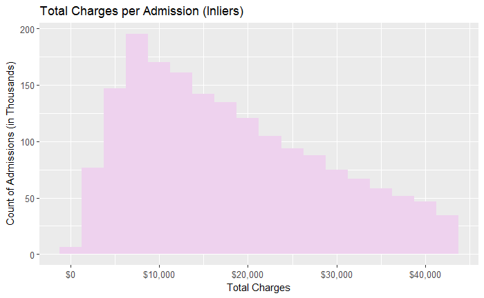

```r
in_charge <- hosp_clean[which(hosp_clean$Total.Charges < 43290),]
ggplot(in_charge, aes(Total.Charges)) + geom_histogram(binwidth=2500, fill="thistle2") + scale_y_continuous(labels=function(x)x/1000) + scale_x_continuous(labels=dollar) + ylab("Count of Admissions (in Thousands)") + xlab("Total Charges") + ggtitle("Total Charges per Admission (Inliers)") + theme(axis.text = element_text(size=10))
```

I chose to consider the inliers for cost as those below the end of the IQR in the dataset, which was $43,294, and to create a histogram of these admissions with a binwidth of $2,500. These charges still formed a right-skewed distribution, but it was much more cohesive, with a single peak around $7,500. Given the widely varying nature of hospital admissions, it is expected that the charges would not form a normal distribution.

I expected that the total costs would form a similar distribution to the total charges in this subset, but with a lower peak as I believed that the costs were always less than or equal to the charges involved in an admission.

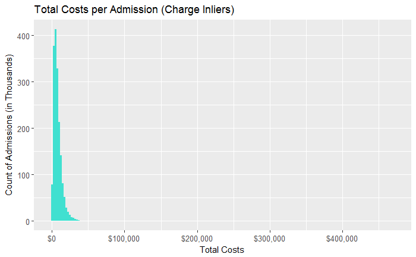

```r
ggplot(in_charge, aes(Total.Costs)) + geom_histogram(binwidth=2500, fill="turquoise") + scale_y_continuous(labels=function(x)x/1000) + ylab("Count of Admissions (in Thousands)") + xlab("Total Costs") + ggtitle("Total Costs per Admission (Charge Inliers)") + theme(axis.text = element_text(size=10)) + scale_x_continuous(labels=dollar)
```

The above histogram showed that my assumption was entirely incorrect - while nearly all of the costs fell below $50,000, there were some very high outliers over $400,000 even within this subset. As such, I created a variable for the ratio of charges to costs.

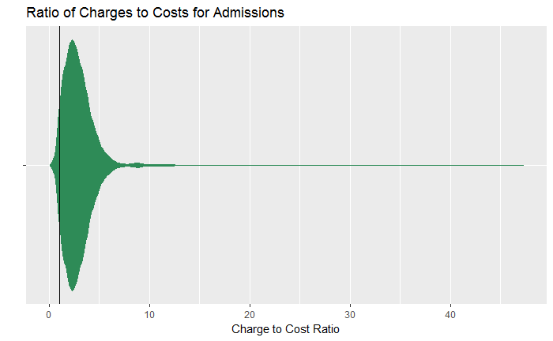

```r
hosp_clean$Charge.to.Cost <- hosp_clean$Total.Charges/hosp_clean$Total.Costs
rat <- hosp_clean[which(hosp_clean$Charge.to.Cost < 1),]
ggplot(hosp_clean, aes(y=Charge.to.Cost, x="")) + geom_violin(fill="seagreen", color="seagreen", bw=0.3) + coord_flip() + xlab("") + ylab("Charge to Cost Ratio") + ggtitle("Ratio of Charges to Costs for Admissions") + geom_hline(yintercept=1)
```

The vertical line in the figure above is at the 1.0 ratio mark, meaning that those admissions falling below it had higher costs than they did charges. This is a much more significant portion of the admissions than I expected, and a quick analysis revealed very little cohesive about these 46,322 admissions (2% of all admissions). However, the peak in the above ratio distribution appears to be around 2, meaning that the majority of admissions cost about half of what the original charges were.

## Charges and Costs per Day

Knowing that there is some cost per day inherent in every hospital admission regardless of the procedure or diagnosis, I created new variables for the costs and charges per day in the dataset. I did not find anything unique in the analysis of the charges per day variable, so I chose to focus on costs per day.

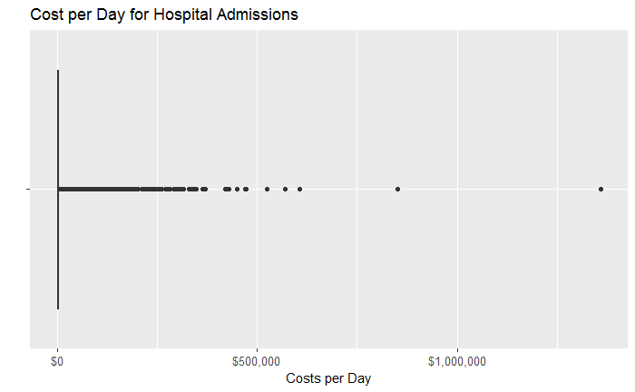

```r
hosp_clean$Cost.Per.Day <- hosp_clean$Total.Costs/hosp_clean$Length.of.Stay
hosp_clean$Charges.Per.Day <- hosp_clean$Total.Charges/hosp_clean$Length.of.Stay
ggplot(hosp_clean, aes(y=Cost.Per.Day, x="")) + geom_boxplot() + coord_flip() + ylab("Costs per Day") + xlab("") + theme(axis.text = element_text(size=10)) + ggtitle("Cost per Day for Hospital Admissions") + scale_y_continuous(labels=dollar)
```

```r
summary(hosp_clean$Cost.Per.Day)
```

```
   Min. 1st Qu.  Median    Mean 3rd Qu.    Max.
      0    1540    2413    3428    4103 1360000
```

```r
out_day_cost <- hosp_clean[which(hosp_clean$Cost.Per.Day > as.numeric(500000)),]
out_day_cost_table <- data.frame(Facility.Name = out_day_cost$Facility.Name, Length.of.Stay = out_day_cost$Length.of.Stay, Patient.Disposition = out_day_cost$Patient.Disposition, CCS.Diagnosis.Description = out_day_cost$CCS.Diagnosis.Description, CCS.Procedure.Description = out_day_cost$CCS.Procedure.Description, Payment.Typology = out_day_cost$Payment.Typology.1, Total.Charges = out_day_cost$Total.Charges, Total.Costs = out_day_cost$Total.Costs)
formattable(out_day_cost_table)
```

| Facility.Name | Length.of.Stay | Patient.Disposition | CCS.Diagnosis.Description | CCS.Procedure.Description | Payment.Typology | Total.Charges | Total.Costs |
| --- | --- | --- | --- | --- | --- | --- | --- |
| University Hospital | 1 | Home or Self Care | HYPERTENSION W/COMPL | OT OR THER PRCS URINARY | Private Health Insurance | 86434.48 | 1359504.8 |
| University Hospital | 3 | Home or Self Care | HYPERTENSION W/COMPL | KIDNEY TRANSPLANT | Blue Cross/Blue Shield | 141496.98 | 1711627.8 |
| University Hospital | 3 | Home or Self Care | HYPERTENSION W/COMPL | KIDNEY TRANSPLANT | Medicare | 136934.98 | 1709825.1 |
| University Hospital | 3 | Home or Self Care | DEVICE/IMPLNT/GRFT COMP | KIDNEY TRANSPLANT | Medicare | 145967.76 | 1712558.3 |
| University Hospital | 4 | Home or Self Care | HYPERTENSION W/COMPL | KIDNEY TRANSPLANT | Medicare | 229916.72 | 3403144.4 |
| Nassau University Medical Center | 1 | Home or Self Care | BREAST CANCER | MASTECTOMY | Medicaid | 44286.50 | 525101.4 |
| Nassau University Medical Center | 1 | Home or Self Care | CONDUCTION DISORDER | CARDIAC PACEMAKER/DEFIB | Medicare | 45907.95 | 606232.1 |

All seven of these admissions with high costs per day had lengths of stay of four days or less, and none were same as the high outliers in the total charges subset. They also all occurred at university hospitals, though there were many other hospitals associated with universities in the dataset. Four were kidney transplants at University Hospital, and one other was also a urinary procedure at the same hospital. The other two were at Nassau University Medical Center and were a mastectomy and a pacemaker insertion, respectively. It is difficult to tell from the data available why these seven admissions in particular had such high costs per day.  
Overall, I was surprised by how difficult it was to investigate the charge and cost data available for these 2014 admissions. There was a great deal of variation, even within admissions that appeared very similar, and I could not even begin to look at the charge/cost ratio by payment typology.

# Conclusion

Even after devoting a great deal of time and effort to exploring this dataset, there are still many questions I have not even touched. There are still a number of variables that could be explored, including type of admission, patient disposition, emergency department status, and payment typology. Future questions could include how the charge to cost ratio differs between payment typology, whether the type of an admission has any bearing on length of stay, diagnosis, and other factors, and the relationship of patient disposition to location, condition, demographics, and procedure. While the size of this dataset allowed me to ask any number of questions, the scale of the data was also a limitation in that many types of visualization were simply not possible/readable with over two million distinct observations. Other limitations included the vague demographic data and the coding of long lengths of stay as simple 120+ days. Many subsets of this data, such as the hospitals or diagnoses, could be analyzed extensively to try to uncover more cohesive patterns. From this analysis, it seems that it is difficult to analyze such large sets of inpatient admission data due to the wide variation in the types of admissions.